# Spatial and Temporal Variations in Microbial Diversity on Foxfonna

Archana Dayal & André Soares

23 January, 2021

## Loading libraries

```r
library(dada2); packageVersion("dada2")
```

```
## [1] '1.16.0'
```

```r
library(ggplot2); packageVersion("ggplot2")
```

```
## [1] '3.3.3'
```

```r
library(phyloseq); packageVersion("phyloseq")
```

```
## [1] '1.30.0'
```

```r
library(data.table); packageVersion("data.table")
```

```
## [1] '1.12.8'
```

```r
library(dplyr)
library(plyr)
library(magrittr)
library(RColorBrewer)
library(picante)
library(igraph)
library(cowplot)
library(plotly)
library(lemon)
library(GGally)
library(randomcoloR)
library(knitr)
library(kableExtra)
library(ggpmisc)
library(ggpubr)
library(decontam)
```

## Importing data

```r
SVt = readRDS("../seqtab_final.rds")
# SVt_cnn = collapseNoMismatch(SVt, minOverlap = 20,
#                               identicalOnly = FALSE, vec = TRUE, verbose = TRUE)
# saveRDS(SVt_cnn, "../seqtab_final_cnn.rds")
# SVt = readRDS("../seqtab_final_cnn.rds")
SVt = SVt[!rownames(SVt) %in% "Undetermined", ]

Tax = readRDS("../tax_final.rds")

metadata<-read.csv("../../220319_for_graph.csv", header=TRUE)
# metadata[, 10:47]  <- as.numeric(metadata[, 10:47])
metadata$Snowpack_Layer = gsub("Glacial Ice", "GL ICE", metadata$Snowpack_Layer)
metadata$Snowpack_Layer = gsub("Sup. Ice", "SUP ICE", metadata$Snowpack_Layer)
metadata$Snowpack_Layer = gsub("Top", "TOP", metadata$Snowpack_Layer)
metadata$Snowpack_Layer = gsub("Mid", "MID", metadata$Snowpack_Layer)
metadata$Snowpack_Layer = gsub("Basal", "BASAL", metadata$Snowpack_Layer)

order<-rownames(SVt)
metadata$Sample_ID=as.character(metadata$Sample_ID)
metadata_ord<-metadata[match(order, metadata$Sample_ID),]
rownames(metadata_ord) <- metadata_ord$Sample_ID
metadata_ord$Sample_Name <- factor(metadata$Sample_Name, levels=unique(metadata$Sample_Name))
ps <- phyloseq(otu_table(SVt, taxa_are_rows=FALSE),
               sample_data(metadata_ord),
               tax_table(Tax))
ps.b <- prune_taxa(taxa_sums(ps) > 0, ps)
ps.b = subset_taxa(ps.b, Kingdom %in% c("Archaea", "Bacteria"))
ps.b = subset_samples(ps.b, Fox_Aspect != "N_NE_D")
```

## Testing batch effects

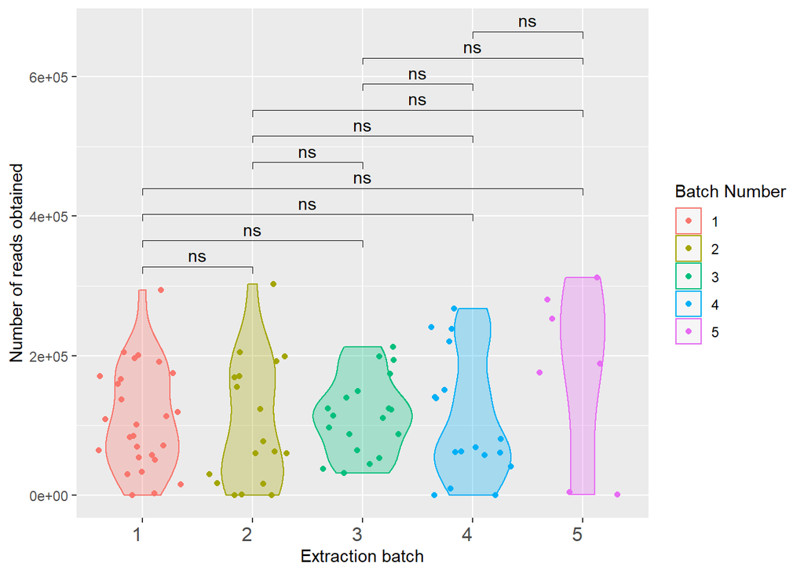

```r
#remove samples with 0 reads
ps.batch = prune_samples(sample_sums(ps.b)>=1, ps.b)

readsumsdf_samples<-data.frame(nreads = sample_sums(ps.batch),
                               samples = rownames(as.data.frame(sample_sums(ps.batch))),
                               batch = sample_data(ps.batch)$Batch.no.)
readsumsdf_samples_f = readsumsdf_samples[- grep("Control", readsumsdf_samples$batch),]

my_comparisons=list(c("1","2"),c("1","3"),c("1","4"),c("1","5"),
                    c("2","3"), c("2","4"), c("2","5"),
                    c("3","4"), c("3","5"),
                    c("4","5"))

ggplot(readsumsdf_samples_f, aes(x=batch, y=nreads,
                                 color=batch, fill=batch)) +
  geom_violin(alpha=0.3) +
  geom_jitter(shape=16, position = "jitter") +
  stat_compare_means(comparisons = my_comparisons,
                     method = "t.test",
                     symnum.args = list(cutpoints = c(0, 0.0001, 0.001, 0.01, 0.05,0.01, 1),
                       symbols = c("p<0.0001", "p<0.001", "p<0.01", "p<0.05","p<0.1", "ns"))) +
  labs(color="Batch Number") +
  guides(fill=FALSE) +
  xlab("Extraction batch") +
  ylab("Number of reads obtained") +
  theme(axis.text.x = element_text(vjust = 1,
                                   hjust = 1,
                                   size = 12),
        strip.text = element_text(size = 12, margin = margin()))
```

## 1 - Library sizes

```r
sort(sample_sums(ps.b))
```

```
##     C05-cDNA-29     D12-cDNA-MM     C10-cDNA-34 A02-cDNA-MM-H20     C08-cDNA-32
##               0               0               5               7              25
##     C07-cDNA-31     B07-cDNA-17 E01-cDNA-MM-H20     B11-cDNA-22     B09-cDNA-19
##              27              43              55             123             187
##     D01-cDNA-37     A01-cDNA-MM      A11-cDNA-9     D10-cDNA-46     B10-cDNA-21
##             262             290            2320            3844            9170
##      A10-cDNA-8     B05-cDNA-15       B08-DNA-4       B11-DNA-7     B08-cDNA-18
##           15595           15781           16781           29350           29808
##     C03-cDNA-27      A08-cDNA-6      A06-cDNA-4      A09-cDNA-7      A07-cDNA-5
##           31806           33041           37485           40604           44392
##       A11-DNA-9      A05-cDNA-3       A08-DNA-6     B02-cDNA-12       D08-DNA-8
##           50662           52562           53872           57398           57493
##      E02-DNA-MM     C02-cDNA-26     D07-cDNA-43       D06-DNA-6       D02-DNA-2
##           58537           59570           59805           60653           61230
##      A01-DNA-MM       B12-DNA-8     B12-cDNA-23      A12-DNA-10       C07-DNA-5
##           61807           62146           62235           63891           64148
##     B04-cDNA-14       A07-DNA-5  A02-DNA-MM-H20      A04-cDNA-2     B03-cDNA-13
##           68029           69142           69499           70613           76895
##       D09-DNA-9      B02-DNA-12       A05-DNA-3     C04-cDNA-28       C05-DNA-3
##           80028           83134           84732           86983           87568
##       C04-DNA-2     D06-cDNA-42       A09-DNA-7     B01-cDNA-11      B04-DNA-14
##           96798          101335          108915          110464          113222
##    C03-DNA-B2-1      B03-DNA-13       C08-DNA-6     A12-cDNA-10     B06-cDNA-16
##          114048          118548          122463          123046          123687
##     C12-cDNA-36     D02-cDNA-38       D03-DNA-3       C06-DNA-4  E03-DNA-MM-H20
##          123719          137347          138813          139808          140502
##       D07-DNA-7      C12-DNA-10       D04-DNA-4       B09-DNA-5     D08-cDNA-44
##          140668          148596          151009          155211          158902
##       A06-DNA-4       C01-DNA-9       B10-DNA-6       A10-DNA-8       C09-DNA-7
##          166098          169126          170463          170498          173577
##      B01-DNA-11       E01-DNA-4     C06-cDNA-30     C09-cDNA-33     D03-cDNA-39
##          174897          175874          188016          190708          192008
##      A03-cDNA-1       A03-DNA-1       B06-DNA-2     C11-cDNA-35       A04-DNA-2
##          193167          196436          198649          198996          200229
##       B07-DNA-3     D04-cDNA-40       C10-DNA-8     D11-cDNA-47    D01-DNA-B4-1
##          204577          204668          212618          220186          238199
##     D09-cDNA-45       D11-DNA-2       D05-DNA-5    D10-DNA-B5-1     C01-cDNA-25
##          240324          252560          267031          280585          293592
##     D05-cDNA-41       D12-DNA-3
##          302761          312011
```

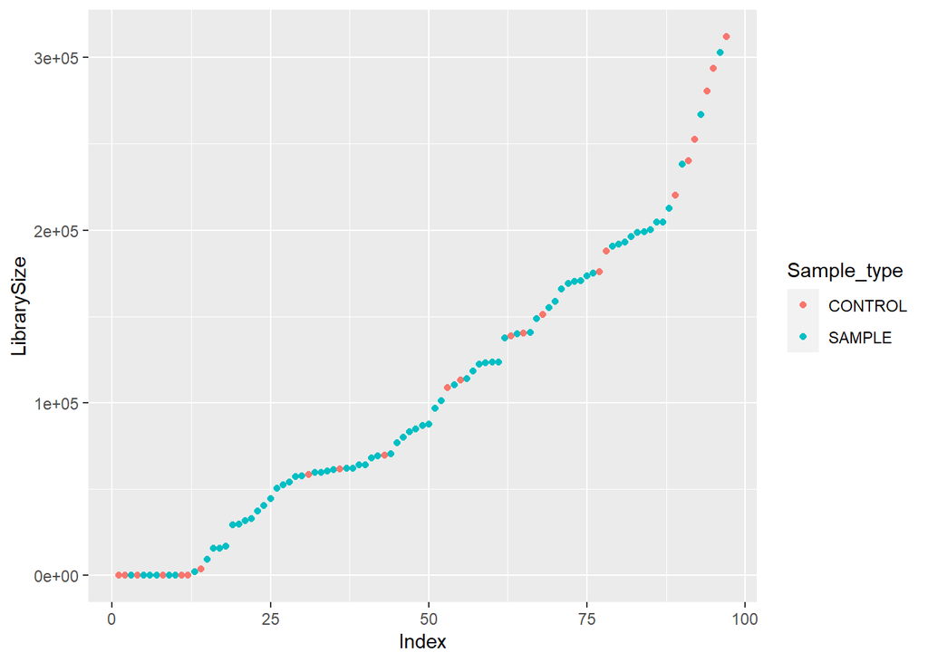

```r
df <- as.data.frame(sample_data(ps.b)) # Put sample_data into a ggplot-friendly data.frame
df$LibrarySize <- sample_sums(ps.b)
df <- df[order(df$LibrarySize),]
df$Index <- seq(nrow(df))
ggplot(data=df, aes(x=Index, y=LibrarySize, color=Sample_type)) + geom_point()
```

## 2 - Evaluating dataset contamination with `decontam`

```r
#remove samples with 0 reads
ps.b = prune_samples(sample_sums(ps.b)>=1, ps.b)

sample_data(ps.b)$is.neg <- sample_data(ps.b)$Sample_type == "CONTROL"
contamdf0.5.prev <- isContaminant(ps.b, method="prevalence", threshold = 0.1,
                               neg="is.neg")

ps.final.noncontam <- prune_taxa(!contamdf0.5.prev$contaminant, ps.b)
ps.final.noncontam.noconts = subset_samples(ps.final.noncontam, Sample_type != "CONTROL")

ps.final.noncontam.noconts.nodoubs = subset_samples(ps.final.noncontam.noconts,
    Sample_ID != "D02-DNA-2" & Sample_ID != "B11-DNA-7" & Sample_ID != "C10-cDNA-34" & Sample_ID != "A08-cDNA-6")

ps.final.noncontam.noconts.nodoubs = prune_samples(sample_sums(ps.final.noncontam.noconts.nodoubs)>=1000,
                                                   ps.final.noncontam.noconts.nodoubs)

ps.final <- prune_taxa(taxa_sums(ps.final.noncontam.noconts.nodoubs) > 0, ps.final.noncontam.noconts.nodoubs)
ps.final = prune_samples(sample_sums(ps.final)>=1, ps.final)

ps.final.r <-  transform_sample_counts(ps.final, function(x) x / sum(x))
ps.final.r.f = filter_taxa(ps.final.r, function(x) sum(x) > .001, TRUE)
ps.final.r
```

```
## phyloseq-class experiment-level object
## otu_table()   OTU Table:         [ 35534 taxa and 65 samples ]
## sample_data() Sample Data:       [ 65 samples by 47 sample variables ]
## tax_table()   Taxonomy Table:    [ 35534 taxa by 6 taxonomic ranks ]
```

```r
ps.final.r.f
```

```
## phyloseq-class experiment-level object
## otu_table()   OTU Table:         [ 2886 taxa and 65 samples ]
## sample_data() Sample Data:       [ 65 samples by 47 sample variables ]
## tax_table()   Taxonomy Table:    [ 2886 taxa by 6 taxonomic ranks ]
```

```r
ps.final
```

```
## phyloseq-class experiment-level object
## otu_table()   OTU Table:         [ 35534 taxa and 65 samples ]
## sample_data() Sample Data:       [ 65 samples by 47 sample variables ]
## tax_table()   Taxonomy Table:    [ 35534 taxa by 6 taxonomic ranks ]
```

```r
sum(rowSums(otu_table(ps.final)))
```

```
## [1] 6750655
```

### Setting order for all plots

```r
sample_data(ps.final.r)$Month = factor(sample_data(ps.final.r)$Month,
                                 levels = c("April","June","Early July", "Late July"))
sample_data(ps.final.r)$Fox_Aspect = factor(sample_data(ps.final.r)$Fox_Aspect,
                                 levels = c("NW_AWS","N_NE","SWS1SE"))
sample_data(ps.final.r)$Snowpack_Layer = factor(sample_data(ps.final.r)$Snowpack_Layer,
                                 levels = c("TOP","MID","BASAL","SUP ICE","GL ICE"))

sample_data(ps.final)$Month = factor(sample_data(ps.final)$Month,
                                 levels = c("April","June","Early July", "Late July"))
sample_data(ps.final)$Fox_Aspect = factor(sample_data(ps.final)$Fox_Aspect,
                                 levels = c("NW_AWS","N_NE","SWS1SE"))
sample_data(ps.final)$Snowpack_Layer = factor(sample_data(ps.final)$Snowpack_Layer,
                                 levels = c("TOP","MID","BASAL","SUP ICE","GL ICE"))

sample_data(ps.final.r.f)$Month = factor(sample_data(ps.final.r.f)$Month,
                                 levels = c("April","June","Early July", "Late July"))
sample_data(ps.final.r.f)$Fox_Aspect = factor(sample_data(ps.final.r.f)$Fox_Aspect,
                                 levels = c("NW_AWS","N_NE","SWS1SE"))
sample_data(ps.final.r.f)$Snowpack_Layer = factor(sample_data(ps.final.r.f)$Snowpack_Layer,
                                 levels = c("TOP","MID","BASAL","SUP ICE","GL ICE"))
```

## 3a - Phyla- and Proteobacterial class-level stacked barchart by DNA_or_cDNA~Fox_Aspect.

```r
ps.final.r.glom <- tax_glom(ps.final.r, taxrank = 'Phylum', NArm = FALSE)
ps.final.r.glom.psdf <- data.table(psmelt(ps.final.r.glom))
ps.final.r.glom.psdf$Phylum <- as.character(ps.final.r.glom.psdf$Phylum)

ps.final.r.glom.psdf[, mean := mean(Abundance, na.rm = TRUE),
                 by = "Phylum"]
ps.final.r.glom.psdf[(mean <= 0.01), Phylum := "Other"]
ps.final.r.glom.psdf$Phylum[is.na(ps.final.r.glom.psdf$Phylum) & ps.final.r.glom.psdf$Kingdom=="Bacteria"] <- "Unc. Bacteria"
ps.final.r.glom.psdf$Phylum[is.na(ps.final.r.glom.psdf$Phylum) & ps.final.r.glom.psdf$Kingdom=="Archaea"] <- "Unc. Archaea"
#Removing Proteobacteria from previous table
ps.final.r.glom.psdf.noProteo<-ps.final.r.glom.psdf[!grepl("Proteobacteria", ps.final.r.glom.psdf$Phylum),]

#New table, with Proteobacterial classes only
ps.final.r.ProtCl = subset_taxa(ps.final.r, Phylum == "Proteobacteria")
ps.final.r.ProtClglom <- tax_glom(ps.final.r.ProtCl, taxrank = 'Class', NArm = FALSE)
ps.final.r.ProtClglom.psdf <- data.table(psmelt(ps.final.r.ProtClglom))
ps.final.r.ProtClglom.psdf$Class <- as.character(ps.final.r.ProtClglom.psdf$Class)

ps.final.r.ProtClglom.psdf[, mean := mean(Abundance, na.rm = TRUE),
                       by = "Class"]
ps.final.r.ProtClglom.psdf[(mean <= 0.001), Class := "Other Proteobacteria"]
ps.final.r.ProtClglom.psdf.noP <- subset(ps.final.r.ProtClglom.psdf, select = -Phylum)

names(ps.final.r.glom.psdf.noProteo)[names(ps.final.r.glom.psdf.noProteo) == 'Phylum'] <- 'Taxa'
names(ps.final.r.ProtClglom.psdf.noP)[names(ps.final.r.ProtClglom.psdf.noP) == 'Class'] <- 'Taxa'
# ps.final.r.glom.psdf.noProteo = subset(ps.final.r.glom.psdf.noProteo, select=-c(Class))
ps.final.r.ProteoClAllPhy <- rbind(ps.final.r.glom.psdf.noProteo, ps.final.r.ProtClglom.psdf.noP)

tol18rainbow=c("#771155", "#AA4488", "#CC99BB", "#114477", "#4477AA", "#77AADD", "#117777", "#44AAAA", "#77CCCC", "#777711", "#AAAA44", "#DDDD77", "#774411", "#AA7744", "#DDAA77", "#771122", "#AA4455")

ps.final.r.ProteoClAllPhy$Taxa = factor(ps.final.r.ProteoClAllPhy$Taxa,
              levels = c("Alphaproteobacteria", "Deltaproteobacteria",
                         "Gammaproteobacteria",
                         "Other Proteobacteria",
                         "Actinobacteria",
                         "Acidobacteria","Bacteroidetes",
                         "Chloroflexi","Cyanobacteria",
                         "Firmicutes","Gemmatimonadetes","Other"))
```

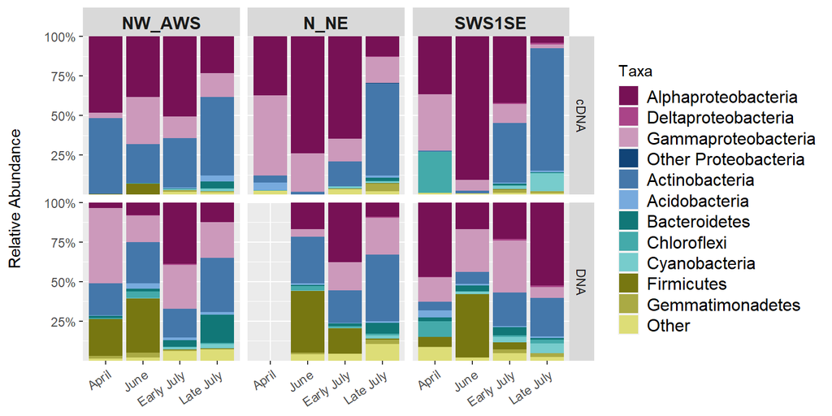

```r
ggplot(ps.final.r.ProteoClAllPhy,
       aes(x = Month, y = Abundance, fill = Taxa)) +
  facet_grid(DNA_or_cDNA~Fox_Aspect,
             scales = "free",
             space = "free") +
  geom_bar(stat = "identity",
           position = "fill") +
  scale_fill_manual(values = tol18rainbow,
                    na.value = "gray40") +
  scale_y_continuous(expand = c(0,0),
                     labels = scales::percent,
                     breaks = c(0.25,0.5,0.75,1)) +
  theme(axis.title.x = element_blank(),
        axis.text.x = element_text(angle = 35, hjust = 1),
        strip.text.x = element_text(face = "bold",
                                    size = 12),
        strip.background = element_rect(size=1),
        legend.text = element_text(size= 12)) +
  guides(fill = guide_legend(keywidth = 1, keyheight = 1)) +
  ylab("Relative Abundance\n")
```

## 3b - Phyla- and Proteobacterial class-level stacked barchart by DNA_or_cDNA~Snowpack_Layer

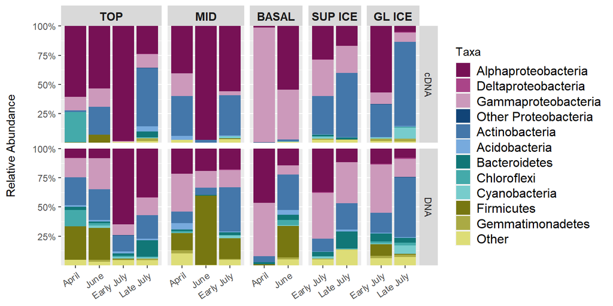

```r
ggplot(ps.final.r.ProteoClAllPhy,
                                   aes(x = Month, y = Abundance, fill = Taxa)) +
  facet_grid(DNA_or_cDNA~Snowpack_Layer,
             scales = "free",
             space = "free") +
  geom_bar(stat = "identity",
           position = "fill") +
  scale_fill_manual(values = tol18rainbow,
                    na.value = "gray40") +
  scale_y_continuous(expand = c(0,0),
                     labels = scales::percent,
                     breaks = c(0.25,0.5,0.75,1)) +
  theme(axis.title.x = element_blank(),
        axis.text.x = element_text(angle = 35, hjust = 1),
        strip.text.x = element_text(face = "bold",
                                    size = 11),
        strip.background = element_rect(size=1),
        legend.text = element_text(size= 12)) +
  guides(fill = guide_legend(keywidth = 1, keyheight = 1)) +
  ylab("Relative Abundance\n")
```

## 3c - Phyla- and Proteobacterial class-level stacked barchart by DNA_or_cDNA~Month

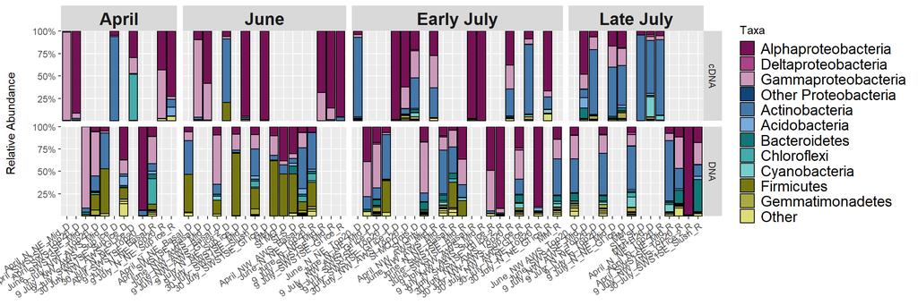

```r
tol17rainbow=c("#771155", "#AA4488", "#CC99BB", "#114477", "#4477AA", "#77AADD", "#117777", "#44AAAA", "#77CCCC", "#777711", "#AAAA44", "#DDDD77", "#774411", "#AA7744", "#DDAA77", "#AA4455")

ggplot(ps.final.r.ProteoClAllPhy,
                                   aes(x = Sample_Name, y = Abundance, fill = Taxa)) +
  facet_grid(DNA_or_cDNA~Month,
             scales = "free",
             space = "free") +
  geom_bar(stat = "identity",
           position = "fill",
           color="black") +
  scale_fill_manual(values = tol17rainbow,
                    na.value = "gray40") +
  scale_y_continuous(expand = c(0,0),
                     labels = scales::percent,
                     breaks = c(0.25,0.5,0.75,1)) +
  theme(axis.title.x = element_blank(),
        axis.text.x = element_text(angle = 35, hjust = 1),
        strip.text.x = element_text(face = "bold",
                                    size = 16),
        strip.background = element_rect(size=1),
        legend.text = element_text(size= 14)) +
  guides(fill = guide_legend(keywidth = 1, keyheight = 1,
                             nrow = )) +
  ylab("Relative Abundance\n")
```

## 4 - Top SVs and their sequences

```r
Top20SVs_names = names(sort(taxa_sums(ps.final.r), TRUE)[1:20])
Top20SVs_names_df=as.data.frame(as(tax_table(prune_taxa(Top20SVs_names, ps.final.r)), "matrix")[,2:6])
rownames(Top20SVs_names_df) = c()
Top20SVs_names_df
```

```
##            Phylum               Class                 Order            Family
## 1  Proteobacteria Alphaproteobacteria           Rhizobiales  Beijerinckiaceae
## 2  Proteobacteria Gammaproteobacteria Betaproteobacteriales  Burkholderiaceae
## 3  Proteobacteria Alphaproteobacteria           Rhizobiales         Labraceae
## 4  Proteobacteria Alphaproteobacteria      Sphingomonadales Sphingomonadaceae
## 5  Proteobacteria Gammaproteobacteria Betaproteobacteriales  Burkholderiaceae
## 6  Proteobacteria Alphaproteobacteria           Rhizobiales Xanthobacteraceae
## 7  Proteobacteria Alphaproteobacteria      Sphingomonadales Sphingomonadaceae
## 8  Proteobacteria Alphaproteobacteria           Rhizobiales  Beijerinckiaceae
## 9  Proteobacteria Alphaproteobacteria      Sphingomonadales Sphingomonadaceae
## 10 Proteobacteria Alphaproteobacteria       Acetobacterales  Acetobacteraceae
## 11 Actinobacteria      Actinobacteria         Micrococcales Microbacteriaceae
## 12 Proteobacteria Gammaproteobacteria Betaproteobacteriales  Burkholderiaceae
## 13 Proteobacteria Alphaproteobacteria      Sphingomonadales Sphingomonadaceae
## 14 Proteobacteria Gammaproteobacteria Betaproteobacteriales  Burkholderiaceae
```

[output cut: 27 more lines]

```r
rownames(as.data.frame(as(tax_table(prune_taxa(Top20SVs_names, ps.final.r)), "matrix")[,2:6]))
```

```
##  [1] "TGGGGAATATTGGACAATGGGCGCAAGCCTGATCCAGCCATGCCGCGTGAGTGATGAAGG…"
##  [2] "TGGGGAATTTTGGACAATGGGGGCAACCCTGATCCAGCAATGCCGCGTGTGTGAAGAAGG…"
##  [3] "TGGGGAATATTGGACAATGGGCGCAAGCCTGATCCAGCCATGCCGCGTGAGTGATGACGG…"
##  [4] "TGGGGAATATTGGACAATGGGCGAAAGCCTGATCCAGCAATGCCGCGTGAGTGATGAAGG…"
##  [5] "TGGGGAATTTTGGACAATGGGGGAAACCCTGATCCAGCAATGCCGCGTGTGTGAAGAAGG…"
##  [6] "TGGGGAATATTGGACAATGGGCGCAAGCCTGATCCAGCCATGCCGCGTGAGTGATGAAGG…"
##  [7] "TGGGGAATATTGGACAATGGGCGAAAGCCTGATCCAGCAATGCCGCGTGAGTGATGAAGG…"
##  [8] "TGGGGAATATTGGACAATGGGCGCAAGCCTGATCCAGCCATGCCGCGTGAGTGATGAAGG…"
##  [9] "TGGGGAATATTGGACAATGGGCGAAAGCCTGATCCAGCAATGCCGCGTGAGTGATGAAGG…"
## [10] "TGGGGAATATTGGACAATGGGCGAAAGCCTGATCCAGCAATGCCGCGTGTGTGAAGAAGG…"
## [11] "TGGGGAATATTGCACAATGGGCGCAAGCCTGATGCAGCAACGCCGCGTGAGGGACGACGG…"
## [12] "TGGGGAATTTTGGACAATGGGCGAAAGCCTGATCCAGCAATGCCGCGTGAGTGAAGAAGG…"
## [13] "TGGGGAATATTGGACAATGGGCGAAAGCCTGATCCAGCAATGCCGCGTGAGTGATGAAGG…"
## [14] "TGGGGAATTTTGGACAATGGGCGAAAGCCTGATCCAGCAATGCCGCGTGCAGGATGAAGG…"
## [15] "TGGGGAATATTGCACAATGGGCGAAAGCCTGATGCAGCGACGCCGCGTGAGGGATGACGG…"
## [16] "TGGGGAATATTGCACAATGGGCGAAAGCCTGATGCAGCGACGCCGCGTGAGGGATGACGG…"
## [17] "TGGGGAATATTGCGCAATGGGCGAAAGCCTGACGCAGCGACGCCGCGTGGGGGATGAAGG…"
## [18] "TGGGGAATATTGCACAATGGGCGAAAGCCTGATGCAGCGACGCCGCGTGAGGGATGGAGG…"
## [19] "TGGGGAATATTGCGCAATGGGCGAAAGCCTGACGCAGCGACGCCGCGTGGGGGATGAAGG…"
## [20] "TGGGGAATATTGCGCAATGGGCGAAAGCCTGACGCAGCGACGCCGCGTGAGGGATGACGG…"
```

## 5b - Genus-level stacked barchart by DNA_or_cDNA~Snowpack_Layer (filter)

```r
ps.final.r.glom.genus.psdf_2 <- data.table(speedyseq::psmelt(ps.final.r.glom.genus))
ps.final.r.glom.genus.psdf_2$Genus <- as.character(ps.final.r.glom.genus.psdf_2$Genus)

ps.final.r.glom.genus.psdf_2[, mean := mean(Abundance, na.rm = TRUE),
                 by = "Genus"]

ps.final.r.glom.genus.psdf_2$Genus[is.na(ps.final.r.glom.genus.psdf_2$Genus) & ps.final.r.glom.genus.psdf_2$Family=="Sphingomonadaceae"] <- "Unc. Sphingomonadaceae"
ps.final.r.glom.genus.psdf_2$Genus[is.na(ps.final.r.glom.genus.psdf_2$Genus) & ps.final.r.glom.genus.psdf_2$Family=="Burkholderiaceae"] <- "Unc. Burkholderiaceae"
ps.final.r.glom.genus.psdf_2$Genus[is.na(ps.final.r.glom.genus.psdf_2$Genus) & ps.final.r.glom.genus.psdf_2$Family=="Labraceae"] <- "Unc. Labraceae"
ps.final.r.glom.genus.psdf_2$Genus[is.na(ps.final.r.glom.genus.psdf_2$Genus) & ps.final.r.glom.genus.psdf_2$Family=="Acetobacteraceae"] <- "Unc. Acetobacteraceae"
ps.final.r.glom.genus.psdf_2$Genus[is.na(ps.final.r.glom.genus.psdf_2$Genus) & ps.final.r.glom.genus.psdf_2$Family=="Microbacteriaceae"] <- "Unc. Microbacteriaceae"
ps.final.r.glom.genus.psdf_2$Genus[is.na(ps.final.r.glom.genus.psdf_2$Genus) & ps.final.r.glom.genus.psdf_2$Family=="Deinococcaceae"] <- "Unc. Deinococcaceae"
ps.final.r.glom.genus.psdf_2$Genus[is.na(ps.final.r.glom.genus.psdf_2$Genus) & ps.final.r.glom.genus.psdf_2$Family=="Gemmatimonaceae"] <- "Unc. Gemmatimonaceae"
ps.final.r.glom.genus.psdf_2$Genus[is.na(ps.final.r.glom.genus.psdf_2$Genus) & ps.final.r.glom.genus.psdf_2$Family=="Intrasporangiaceae"] <- "Unc. Intrasporangiaceae"
ps.final.r.glom.genus.psdf_2$Genus[is.na(ps.final.r.glom.genus.psdf_2$Genus) &          ps.final.r.glom.genus.psdf_2$Family=="Nocardiaceae"] <- "Unc. Nocardiaceae"
ps.final.r.glom.genus.psdf_2$Genus[is.na(ps.final.r.glom.genus.psdf_2$Genus) &          ps.final.r.glom.genus.psdf_2$Family=="Ktedonobacteraceae"] <- "Unc. Ktedonobacteraceae"
ps.final.r.glom.genus.psdf_2$Genus[is.na(ps.final.r.glom.genus.psdf_2$Genus) &          ps.final.r.glom.genus.psdf_2$Family=="Cellulomonadaceae"] <- "Unc. Cellulomonadaceae"
ps.final.r.glom.genus.psdf_2$Genus[is.na(ps.final.r.glom.genus.psdf_2$Genus) &          ps.final.r.glom.genus.psdf_2$Family=="Beijerinckiaceae"] <- "Unc. Beijerinckiaceae"
ps.final.r.glom.genus.psdf_2$Genus[is.na(ps.final.r.glom.genus.psdf_2$Genus) &          is.na(ps.final.r.glom.genus.psdf_2$Family)] <- "Unclassified"
ps.final.r.glom.genus.psdf_2$Genus[is.na(ps.final.r.glom.genus.psdf_2$Genus) &  is.na(ps.final.r.glom.genus.psdf_2$Family) & ps.final.r.glom.genus.psdf_2$Order=="Frankiales"] <- "Unc. Frankiales"

ps.final.r.glom.genus.psdf_2[(mean <= 0.01), Genus := "Other (<1%)"]

ps.final.r.glom.genus.psdf_2$Genus = factor(ps.final.r.glom.genus.psdf_2$Genus,
                         levels = c("Acidiphilium","Arthrobacter",
                                    "Bacillus",
                                    "Bosea",
                                  "Burkholderia-Caballeronia-Paraburkholderia",
                                    "Cryobacterium","Cupriavidus",
                                    "Delftia","Hymenobacter",
                                    "Labrys","Leptothrix",
                                    "Massilia","Methylobacterium",
                                    "Noviherbaspirillum","Oryzihumus",
                                    "Polymorphobacter",
                                    "Salinibacterium",
                                    "Sphingomonas","Other (<1%)"))
```

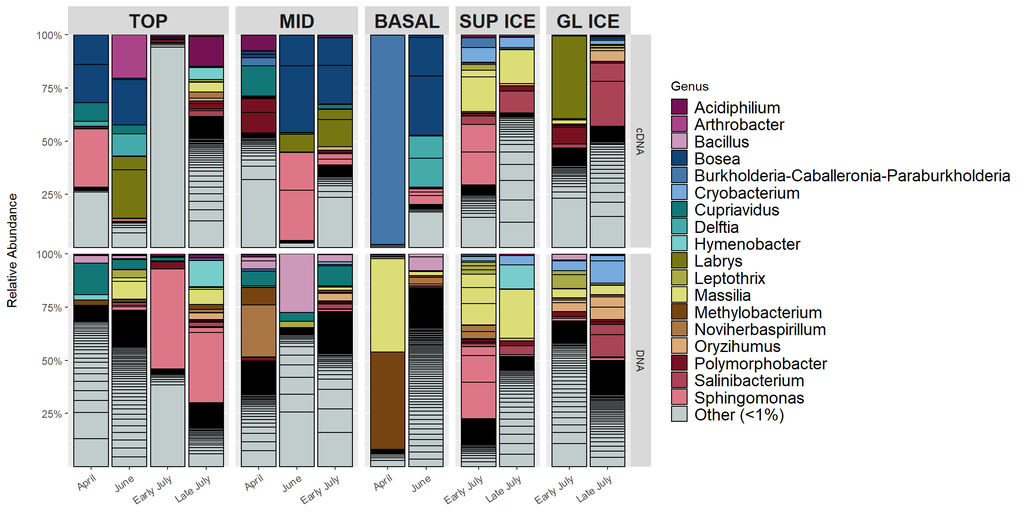

```r
tol17rainbow=c("#771155", "#AA4488", "#CC99BB", "#114477",
               "#4477AA", "#77AADD", "#117777", "#44AAAA",
               "#77CCCC", "#777711", "#AAAA44", "#DDDD77",
               "#774411", "#AA7744", "#DDAA77", "#771122",
               "#AA4455", "#DD7788", "azure3")

ggplot(ps.final.r.glom.genus.psdf_2,
       aes(x = Month, y = Abundance, fill = Genus)) +
  facet_grid(DNA_or_cDNA~Snowpack_Layer,
             scales = "free",
             space = "free") +
  geom_bar(stat = "identity",
           position = "fill",
           color="black") +
  scale_fill_manual(values = tol17rainbow,
                    na.value = "gray40") +
  scale_y_continuous(expand = c(0,0),
                     labels = scales::percent,
                     breaks = c(0.25,0.5,0.75,1)) +
  theme(axis.title.x = element_blank(),
        axis.text.x = element_text(angle = 35, hjust = 1),
        strip.text.x = element_text(face = "bold",
                                    size = 16),
        strip.background = element_rect(size=1),
        legend.text = element_text(size= 14)) +
  guides(fill = guide_legend(keywidth = 1, keyheight = 1,
                             nrow = )) +
  ylab("Relative Abundance\n")
```

## 5b - Genus-level stacked barchart by DNA_or_cDNA~Fox_Aspect (filter)

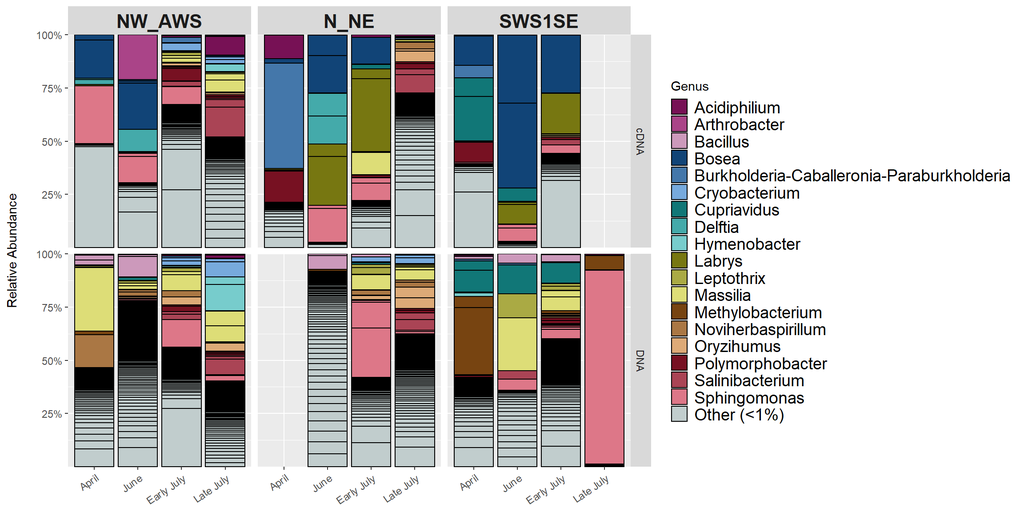

```r
ggplot(ps.final.r.glom.genus.psdf_2,
                                   aes(x = Month, y = Abundance, fill = Genus)) +
  facet_grid(DNA_or_cDNA~Fox_Aspect,
             scales = "free",
             space = "free") +
  geom_bar(stat = "identity",
           position = "fill",
           color="black") +
  scale_fill_manual(values = tol17rainbow,
                    na.value = "gray40") +
  scale_y_continuous(expand = c(0,0),
                     labels = scales::percent,
                     breaks = c(0.25,0.5,0.75,1)) +
  theme(axis.title.x = element_blank(),
        axis.text.x = element_text(angle = 35, hjust = 1),
        strip.text.x = element_text(face = "bold",
                                    size = 16),
        strip.background = element_rect(size=1),
        legend.text = element_text(size= 14)) +
  guides(fill = guide_legend(keywidth = 1, keyheight = 1,
                             nrow = )) +
  ylab("Relative Abundance\n")
```

Lest us not forget that size of Other (<1%) corresponds to the different samples included in that category.

I don’t like this, but plotting all samples now, without grouping.

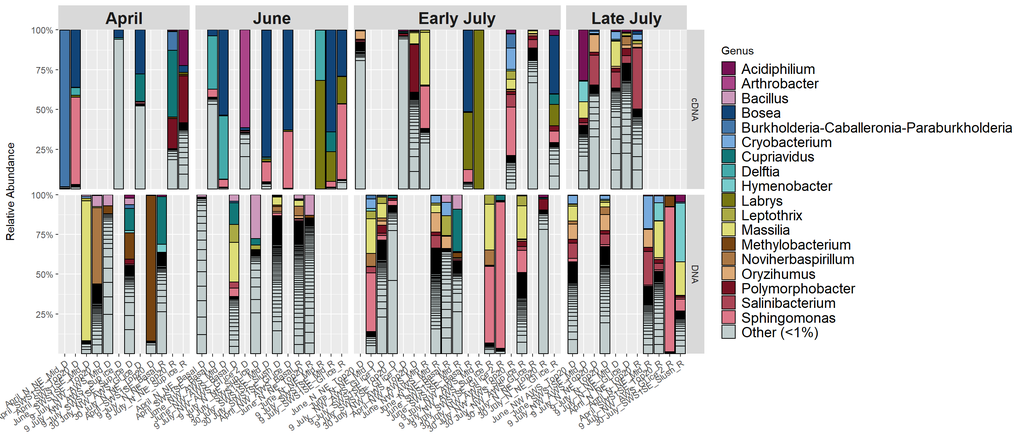

```r
# ps.final.r.glom.genus.psdf_2$Sample_Name <- as.character(ps.final.r.glom.genus.psdf_2$Sample_Name)
# ps.final.r.glom.genus.psdf_2$Sample_Name <- factor(ps.final.r.glom.genus.psdf_2$Sample_Name,
#                                                  levels=unique(ps.final.r.glom.genus.psdf_2$Sample_Name))
ggplot(ps.final.r.glom.genus.psdf_2,
                                   aes(x = Sample_Name, y = Abundance, fill = Genus)) +
  facet_grid(DNA_or_cDNA~Month,
             scales = "free",
             space = "free") +
  geom_bar(stat = "identity",
           position = "fill",
           color="black") +
  scale_fill_manual(values = tol17rainbow,
                    na.value = "gray40") +
  scale_y_continuous(expand = c(0,0),
                     labels = scales::percent,
                     breaks = c(0.25,0.5,0.75,1)) +
  theme(axis.title.x = element_blank(),
        axis.text.x = element_text(angle = 35, hjust = 1),
        strip.text.x = element_text(face = "bold",
                                    size = 16),
        strip.background = element_rect(size=1),
        legend.text = element_text(size= 14)) +
  guides(fill = guide_legend(keywidth = 1, keyheight = 1,
                             nrow = )) +
  ylab("Relative Abundance\n")
```

## 6 - Unconstrained ordination

```r
nmds_shapes = c(15,16,17,18,6)
nmdscolors_by_month = c("April" = "#A6048B",
                        "June" = "#0704A6",
                        "Early July" = "#727A0B",
                        "Late July" = "#6C0504")
nmdscolors_by_snpl = c("Top" = "#151AC6",
                       "Mid" = "#C6156D",
                       "Basal" = "#890909",
                       "Sup. Ice" = "#091D89",
                       "Glacial Ice" = "#580303")

ps.final.r.dna = subset_samples(ps.final.r, DNA_or_cDNA != "cDNA")
ps.final.r.cdna = subset_samples(ps.final.r, DNA_or_cDNA != "DNA")

ps.final.r.dna.nmds  <- ordinate(ps.final.r.dna,
                         "NMDS",
                         distance="jsd",
                         maxit = 1e3)
```

```
## *** No convergence -- monoMDS stopping criteria:
##     20: stress ratio > sratmax
```

```r
ps.final.r.cdna.nmds  <- ordinate(ps.final.r.cdna,
                         "NMDS",
                         distance="jsd",
                         maxit = 1e3)
```

```
## *** No convergence -- monoMDS stopping criteria:
##     20: stress ratio > sratmax
```

```r
ps.final.r.dna.nmds.plot <- plot_ordination(ps.final.r.dna, ps.final.r.dna.nmds) +
               geom_point(aes(colour=Month, shape=Snowpack_Layer),
                          size=5, alpha = 0.5, stroke=1.5) +
               scale_shape_manual(values=nmds_shapes) +
               scale_colour_manual(values=nmdscolors_by_month) +
               scale_fill_manual(values=nmdscolors_by_month) +
               stat_ellipse(aes(fill=Month),
                          geom = "polygon",
                          type="t",
                          alpha=0.15,
                          linetype = 2,
                          show.legend = FALSE) +
  ggtitle("DNA nMDS") +
  guides(colour = guide_legend(title="Month"))

ps.final.r.cdna.nmds.plot <- plot_ordination(ps.final.r.cdna, ps.final.r.cdna.nmds) +
               geom_point(aes(colour=Month, shape=Snowpack_Layer),
                          size=5, alpha = 0.7, stroke=1.5) +
               scale_shape_manual(values=nmds_shapes) +
               scale_colour_manual(values=nmdscolors_by_month) +
               scale_fill_manual(values=nmdscolors_by_month) +
               stat_ellipse(aes(fill=Month),
                          geom = "polygon",
                          type="t",
                          alpha=0.2,
                          linetype = 2,
                          show.legend = FALSE)+
  ggtitle("cDNA nMDS") +
  guides(colour = guide_legend(title="Month"))
```

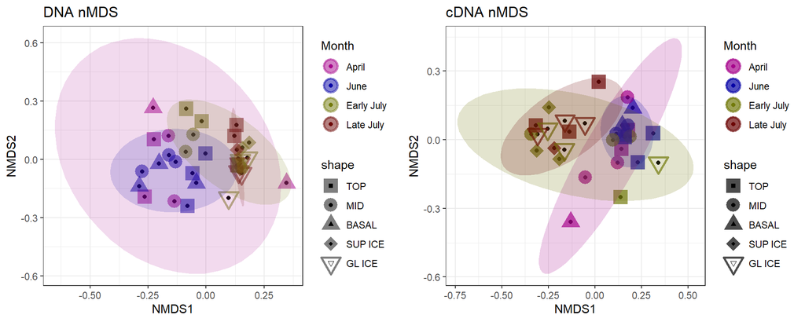

```r
plot_grid(ps.final.r.dna.nmds.plot + theme_bw(),
          ps.final.r.cdna.nmds.plot + theme_bw())
```

## 7 - Alpha-diversity metrics.

```r
month_comparisons = list( c("April", "June"), c("April", "Early July"),
                          c("April", "Late July"),
                          c("June", "Early July"), c("June", "Late July"),
                          c("Early July", "Late July"))

site_comparisons = list( c("NW_AWS", "N_NE"),
                         c("NW_AWS", "SWS1SE"),
                         c("N_NE", "SWS1SE"))

slayer_comparisons = list( c("TOP", "MID"), c("TOP", "BASAL"), c("TOP", "SUP ICE"),
                           c("TOP", "GL ICE"),
                           c("MID", "BASAL"), c("MID", "SUP ICE"),
                           c("MID", "GL ICE"),
                           c("BASAL", "SUP ICE"), c("BASAL", "GL ICE"),
                           c("SUP ICE", "GL ICE"))
```

### All measures for Sample_ID, no stats, facet by DNA/cDNA

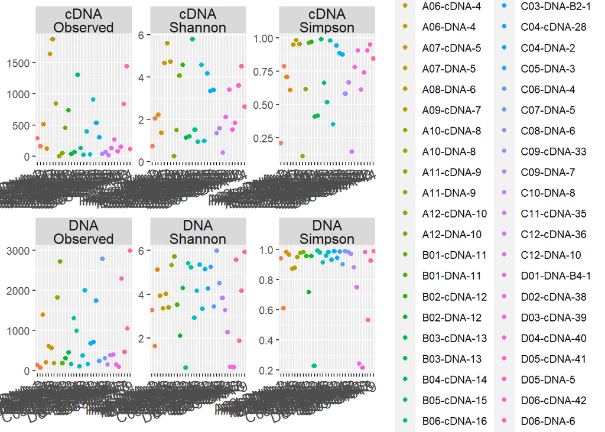

```r
plot_richness(ps.final,
              x="Sample_ID", color="Sample_ID",
              measures=c("Observed","Shannon","Simpson")) +
  geom_jitter(shape=16, position=position_jitter(0.2)) +
  facet_wrap(DNA_or_cDNA~variable, scales = "free") +
  labs(color="Sample_ID") +
  guides(color=guide_legend(ncol=2)) +
  theme(axis.text.x = element_text(angle = 20,
                                   vjust = 1,
                                   hjust = 1,
                                   size = 12),
        axis.title = element_blank(),
        strip.text = element_text(size = 12, margin = margin()))
```

### All measures for Month, stats included, facet by DNA/cDNA

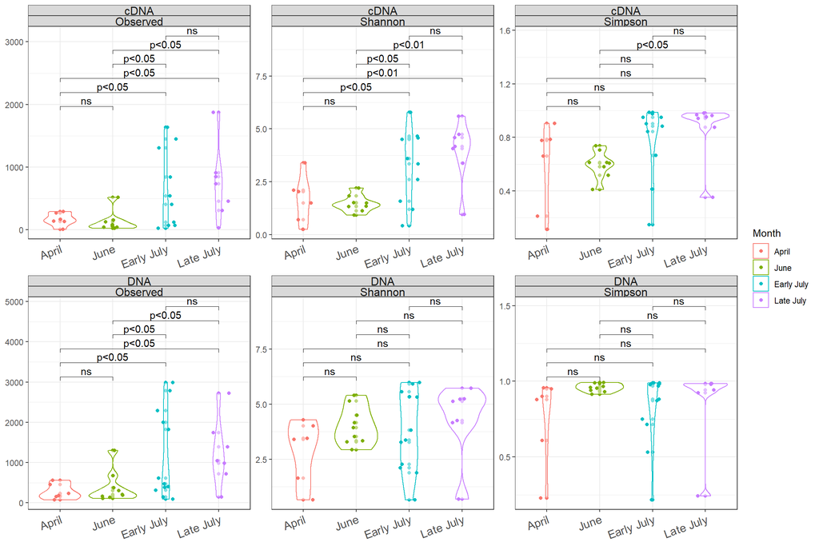

```r
plot_richness(ps.final,
              x="Month", color="Month",
              measures=c("Observed","Shannon","Simpson")) +
  geom_violin(alpha = .5) +
  geom_jitter(shape=16, position=position_jitter(0.2)) +
  facet_wrap(DNA_or_cDNA~variable, scales = "free") +
  # stat_compare_means(comparisons = my_comparisons)+
  stat_compare_means(comparisons = month_comparisons,
                     method = "t.test",
                     var.equal="welch",
                     label.x.npc = "right",
                     label.y.npc = "top",
                     symnum.args = list(cutpoints = c(0, 0.0001, 0.001, 0.01, 0.05,0.01, 1),
                     symbols = c("p<0.0001", "p<0.001", "p<0.01", "p<0.05","p<0.1", "ns"))) +
  labs(color="Month") +
  theme_bw() +
  theme(axis.text.x = element_text(angle = 20,
                                   vjust = 1,
                                   hjust = 1,
                                   size = 12),
        axis.title = element_blank(),
        strip.text = element_text(size = 12, margin = margin()))
```

### All measures for Month, stats included, facet by DNA/cDNA, no (“Early July”, “Late July”)

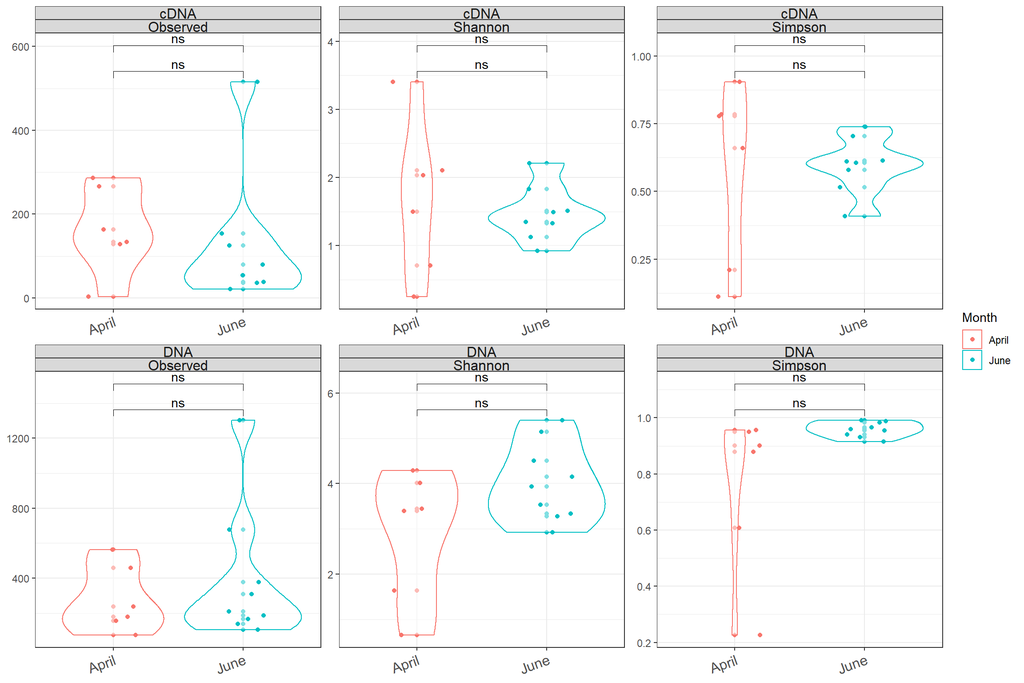

```r
mini_month_comparisons = list(c("April", "June"),
                          c("April", "June"))

plot_richness(subset_samples(ps.final, Month != "Early July" & Month != "Late July"),
              x="Month", color="Month",
              measures=c("Observed","Shannon","Simpson")) +
  geom_violin(alpha = .5) +
  geom_jitter(shape=16, position=position_jitter(0.2)) +
  facet_wrap(DNA_or_cDNA~variable, scales = "free") +
  # stat_compare_means(comparisons = my_comparisons)+
  stat_compare_means(comparisons = mini_month_comparisons,
                     method = "t.test",
                     var.equal="welch",
                     label.x.npc = "right",
                     label.y.npc = "top",
                     symnum.args = list(cutpoints = c(0, 0.0001, 0.001, 0.01, 0.05,0.01, 1),
                     symbols = c("p<0.0001", "p<0.001", "p<0.01", "p<0.05","p<0.1", "ns"))) +
  labs(color="Month") +
  theme_bw() +
  theme(axis.text.x = element_text(angle = 20,
                                   vjust = 1,
                                   hjust = 1,
                                   size = 12),
        axis.title = element_blank(),
        strip.text = element_text(size = 12, margin = margin()))
```

### All measures for Fox_Aspect, no stats, facet by DNA/cDNA

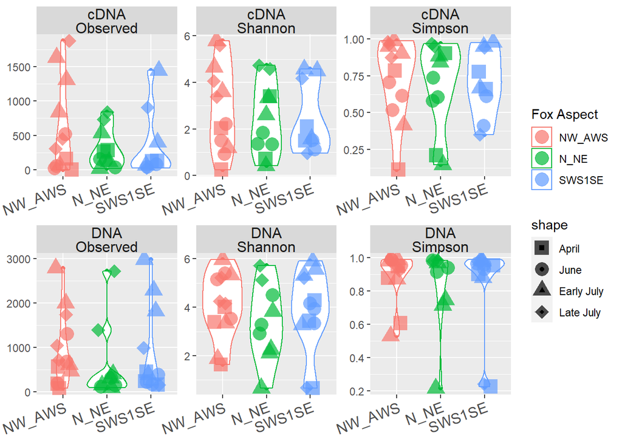

```r
#now without stats, only shapes
plot_richness(ps.final,
              x="Fox_Aspect", color="Fox_Aspect",
              measures=c("Observed","Shannon","Simpson")) +
  geom_violin() +
  geom_jitter(aes(shape=Month), size=5, alpha=0.7,
              position=position_jitter(0.2)) +
  facet_wrap(DNA_or_cDNA~variable, scales = "free") +
  labs(color="Fox Aspect") +
  scale_shape_manual(values=nmds_shapes) +
  theme(axis.text.x = element_text(angle = 20,
                                   vjust = 1,
                                   hjust = 1,
                                   size = 12),
        axis.title = element_blank(),
        strip.text = element_text(size = 12, margin = margin()))
```

### All measures for Fox_Aspect, stats included, facet by DNA/cDNA

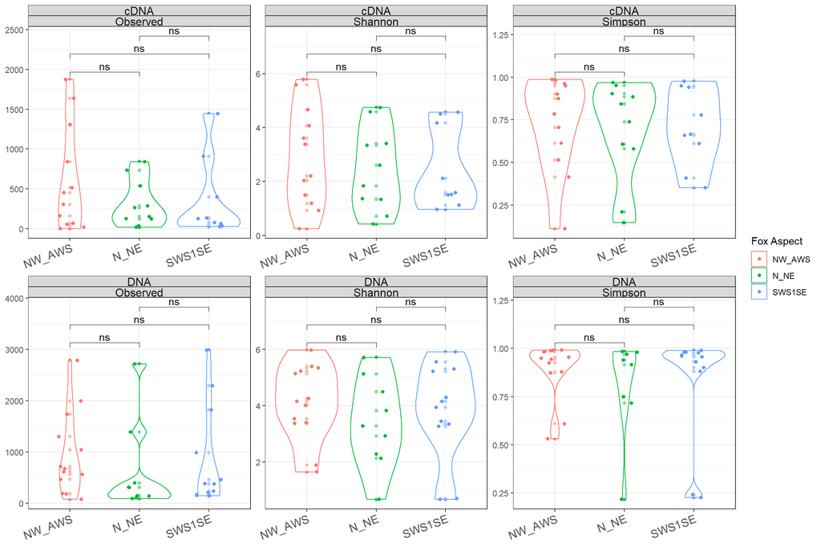

```r
plot_richness(ps.final,
              x="Fox_Aspect", color="Fox_Aspect",
              measures=c("Observed","Shannon","Simpson")) +
  geom_violin(alpha=0.5) +
  geom_jitter(shape=16, position=position_jitter(0.2)) +
  facet_wrap(DNA_or_cDNA~variable, scales = "free") +
  # stat_compare_means(comparisons = my_comparisons)+
  stat_compare_means(comparisons = site_comparisons,
                     method = "t.test",
                     var.equal="welch",
                     label.x.npc = "right",
                     label.y.npc = "top",
                     symnum.args = list(cutpoints = c(0, 0.0001, 0.001, 0.01, 0.05,0.01, 1),
                     symbols = c("p<0.0001", "p<0.001", "p<0.01", "p<0.05","p<0.1", "ns"))) +
  labs(color="Fox Aspect") +
  theme_bw() +
  theme(axis.text.x = element_text(angle = 20,
                                   vjust = 1,
                                   hjust = 1,
                                   size = 12),
        axis.title = element_blank(),
        strip.text = element_text(size = 12, margin = margin()))
```